# Human activity recognition (assignment write-up)

Baranov Dmitry

February 2018

## Overview

In this write-up, I will build the prediction model to recognize human activities by data from accelerometers on the belt, forearm, arm, and measure of 6 participants. They were asked to perform barbell lifts correctly and incorrectly in 5 different ways. More information is available from the website here: http://web.archive.org/web/20161224072740/http:/groupware.les.inf.puc-rio.br/har (see the section on the Weight Lifting Exercise Dataset).

Many thanks to the authors of research for provided data set.  
Velloso, E.; Bulling, A.; Gellersen, H.; Ugulino, W.; Fuks, H. Qualitative Activity Recognition of Weight Lifting Exercises. Proceedings of 4th International Conference in Cooperation with SIGCHI (Augmented Human ’13). Stuttgart, Germany: ACM SIGCHI, 2013. Read more: http://groupware.les.inf.puc-rio.br/har#ixzz57SnmRkTD

## Data loading

The training data for this project are available here: https://d396qusza40orc.cloudfront.net/predmachlearn/pml-training.csv

The test data are available here: https://d396qusza40orc.cloudfront.net/predmachlearn/pml-testing.csv

The has been loaded and placed in a folder with processing scripts.

```r
data.raw <- read.csv("./pml-training.csv", header = TRUE, na.strings = c("","NA","#DIV/0!"))
data <- tbl_df(data.raw)
data
```

```
## # A tibble: 19,622 x 160
##        X user_name raw_timestamp_part~ raw_timestamp_part~ cvtd_timestamp
##    <int> <fct>                   <int>               <int> <fct>
##  1     1 carlitos           1323084231              788290 05/12/2011 11:~
##  2     2 carlitos           1323084231              808298 05/12/2011 11:~
##  3     3 carlitos           1323084231              820366 05/12/2011 11:~
##  4     4 carlitos           1323084232              120339 05/12/2011 11:~
##  5     5 carlitos           1323084232              196328 05/12/2011 11:~
##  6     6 carlitos           1323084232              304277 05/12/2011 11:~
##  7     7 carlitos           1323084232              368296 05/12/2011 11:~
##  8     8 carlitos           1323084232              440390 05/12/2011 11:~
##  9     9 carlitos           1323084232              484323 05/12/2011 11:~
## 10    10 carlitos           1323084232              484434 05/12/2011 11:~
## # ... with 19,612 more rows, and 155 more variables: new_window <fct>,
## #   num_window <int>, roll_belt <dbl>, pitch_belt <dbl>, yaw_belt <dbl>,
## #   total_accel_belt <int>, kurtosis_roll_belt <dbl>,
## #   kurtosis_picth_belt <dbl>, kurtosis_yaw_belt <lgl>,
## #   skewness_roll_belt <dbl>, skewness_roll_belt.1 <dbl>,
## #   skewness_yaw_belt <lgl>, max_roll_belt <dbl>, max_picth_belt <int>,
## #   max_yaw_belt <dbl>, min_roll_belt <dbl>, min_pitch_belt <int>,
## #   min_yaw_belt <dbl>, amplitude_roll_belt <dbl>,
## #   amplitude_pitch_belt <int>, amplitude_yaw_belt <dbl>,
## #   var_total_accel_belt <dbl>, avg_roll_belt <dbl>,
## #   stddev_roll_belt <dbl>, var_roll_belt <dbl>, avg_pitch_belt <dbl>,
## #   stddev_pitch_belt <dbl>, var_pitch_belt <dbl>, avg_yaw_belt <dbl>,
## #   stddev_yaw_belt <dbl>, var_yaw_belt <dbl>, gyros_belt_x <dbl>,
## #   gyros_belt_y <dbl>, gyros_belt_z <dbl>, accel_belt_x <int>,
## #   accel_belt_y <int>, accel_belt_z <int>, magnet_belt_x <int>,
## #   magnet_belt_y <int>, magnet_belt_z <int>, roll_arm <dbl>,
## #   pitch_arm <dbl>, yaw_arm <dbl>, total_accel_arm <int>,
## #   var_accel_arm <dbl>, avg_roll_arm <dbl>, stddev_roll_arm <dbl>,
## #   var_roll_arm <dbl>, avg_pitch_arm <dbl>, stddev_pitch_arm <dbl>,
## #   var_pitch_arm <dbl>, avg_yaw_arm <dbl>, stddev_yaw_arm <dbl>,
## #   var_yaw_arm <dbl>, gyros_arm_x <dbl>, gyros_arm_y <dbl>,
## #   gyros_arm_z <dbl>, accel_arm_x <int>, accel_arm_y <int>,
## #   accel_arm_z <int>, magnet_arm_x <int>, magnet_arm_y <int>,
## #   magnet_arm_z <int>, kurtosis_roll_arm <dbl>, kurtosis_picth_arm <dbl>,
## #   kurtosis_yaw_arm <dbl>, skewness_roll_arm <dbl>,
## #   skewness_pitch_arm <dbl>, skewness_yaw_arm <dbl>, max_roll_arm <dbl>,
## #   max_picth_arm <dbl>, max_yaw_arm <int>, min_roll_arm <dbl>,
## #   min_pitch_arm <dbl>, min_yaw_arm <int>, amplitude_roll_arm <dbl>,
## #   amplitude_pitch_arm <dbl>, amplitude_yaw_arm <int>,
## #   roll_dumbbell <dbl>, pitch_dumbbell <dbl>, yaw_dumbbell <dbl>,
## #   kurtosis_roll_dumbbell <dbl>, kurtosis_picth_dumbbell <dbl>,
## #   kurtosis_yaw_dumbbell <lgl>, skewness_roll_dumbbell <dbl>,
## #   skewness_pitch_dumbbell <dbl>, skewness_yaw_dumbbell <lgl>,
## #   max_roll_dumbbell <dbl>, max_picth_dumbbell <dbl>,
## #   max_yaw_dumbbell <dbl>, min_roll_dumbbell <dbl>,
## #   min_pitch_dumbbell <dbl>, min_yaw_dumbbell <dbl>,
## #   amplitude_roll_dumbbell <dbl>, amplitude_pitch_dumbbell <dbl>,
## #   amplitude_yaw_dumbbell <dbl>, total_accel_dumbbell <int>,
## #   var_accel_dumbbell <dbl>, avg_roll_dumbbell <dbl>,
## #   stddev_roll_dumbbell <dbl>, ...
```

## Exploration of data

The quick review tells me that data has a lot of missing values. The following code gives me an estimation of the volume of missing values.

```r
colSums(is.na(data))
```

```
##                        X                user_name     raw_timestamp_part_1
##                        0                        0                        0
##     raw_timestamp_part_2           cvtd_timestamp               new_window
##                        0                        0                        0
##               num_window                roll_belt               pitch_belt
##                        0                        0                        0
##                 yaw_belt         total_accel_belt       kurtosis_roll_belt
##                        0                        0                    19226
##      kurtosis_picth_belt        kurtosis_yaw_belt       skewness_roll_belt
##                    19248                    19622                    19225
##     skewness_roll_belt.1        skewness_yaw_belt            max_roll_belt
##                    19248                    19622                    19216
##           max_picth_belt             max_yaw_belt            min_roll_belt
##                    19216                    19226                    19216
##           min_pitch_belt             min_yaw_belt      amplitude_roll_belt
##                    19216                    19226                    19216
##     amplitude_pitch_belt       amplitude_yaw_belt     var_total_accel_belt
##                    19216                    19226                    19216
##            avg_roll_belt         stddev_roll_belt            var_roll_belt
##                    19216                    19216                    19216
##           avg_pitch_belt        stddev_pitch_belt           var_pitch_belt
##                    19216                    19216                    19216
##             avg_yaw_belt          stddev_yaw_belt             var_yaw_belt
##                    19216                    19216                    19216
##             gyros_belt_x             gyros_belt_y             gyros_belt_z
##                        0                        0                        0
##             accel_belt_x             accel_belt_y             accel_belt_z
##                        0                        0                        0
##            magnet_belt_x            magnet_belt_y            magnet_belt_z
##                        0                        0                        0
##                 roll_arm                pitch_arm                  yaw_arm
##                        0                        0                        0
##          total_accel_arm            var_accel_arm             avg_roll_arm
##                        0                    19216                    19216
##          stddev_roll_arm             var_roll_arm            avg_pitch_arm
##                    19216                    19216                    19216
##         stddev_pitch_arm            var_pitch_arm              avg_yaw_arm
##                    19216                    19216                    19216
##           stddev_yaw_arm              var_yaw_arm              gyros_arm_x
##                    19216                    19216                        0
```

[output cut: 53 more lines]

```
##                    19300                        0                    19216
##         avg_roll_forearm      stddev_roll_forearm         var_roll_forearm
##                    19216                    19216                    19216
##        avg_pitch_forearm     stddev_pitch_forearm        var_pitch_forearm
##                    19216                    19216                    19216
##          avg_yaw_forearm       stddev_yaw_forearm          var_yaw_forearm
##                    19216                    19216                    19216
##          gyros_forearm_x          gyros_forearm_y          gyros_forearm_z
##                        0                        0                        0
##          accel_forearm_x          accel_forearm_y          accel_forearm_z
##                        0                        0                        0
##         magnet_forearm_x         magnet_forearm_y         magnet_forearm_z
##                        0                        0                        0
##                   classe
##                        0
```

To impute the missing values I have selected to replace them by a mean value.

```r
for(cl in which(colSums(is.na(data))>0))
    data[is.na(data[[cl]]), cl] <- mean(data[[cl]], na.rm = TRUE)
```

Now I will check the data for variables with zero and near zero variance.

```r
zero <- nearZeroVar(data,saveMetrics=TRUE)
zero
```

```
##                             freqRatio percentUnique zeroVar   nzv
## X                            1.000000  100.00000000   FALSE FALSE
## user_name                    1.100679    0.03057792   FALSE FALSE
## raw_timestamp_part_1         1.000000    4.26562022   FALSE FALSE
## raw_timestamp_part_2         1.000000   85.53154622   FALSE FALSE
## cvtd_timestamp               1.000668    0.10192641   FALSE FALSE
## new_window                  47.330049    0.01019264   FALSE  TRUE
## num_window                   1.000000    4.37264295   FALSE FALSE
## roll_belt                    1.101904    6.77810621   FALSE FALSE
## pitch_belt                   1.036082    9.37722964   FALSE FALSE
## yaw_belt                     1.058480    9.97349913   FALSE FALSE
## total_accel_belt             1.063160    0.14779329   FALSE FALSE
## kurtosis_roll_belt        9613.000000    2.01814290   FALSE  TRUE
## kurtosis_picth_belt       4812.000000    1.61043726   FALSE  TRUE
## kurtosis_yaw_belt            0.000000    0.00000000    TRUE  TRUE
## skewness_roll_belt        4806.250000    2.00795026   FALSE  TRUE
## skewness_roll_belt.1      4812.000000    1.71745999   FALSE  TRUE
## skewness_yaw_belt            0.000000    0.00000000    TRUE  TRUE
## max_roll_belt             1746.909091    0.99887881   FALSE  TRUE
## max_picth_belt             192.160000    0.11721537   FALSE  TRUE
## max_yaw_belt               640.866667    0.34145347   FALSE  TRUE
## min_roll_belt             1601.333333    0.94281928   FALSE  TRUE
## min_pitch_belt             168.561404    0.08663745   FALSE  TRUE
## min_yaw_belt               640.866667    0.34145347   FALSE  TRUE
## amplitude_roll_belt        480.400000    0.75935175   FALSE  TRUE
## amplitude_pitch_belt        88.962963    0.07134849   FALSE  TRUE
## amplitude_yaw_belt           0.000000    0.00509632    TRUE  TRUE
## var_total_accel_belt       164.239316    0.33635715   FALSE  TRUE
## avg_roll_belt             1201.000000    0.97849353   FALSE  TRUE
## stddev_roll_belt           362.566038    0.35674243   FALSE  TRUE
## var_roll_belt              152.507937    0.49434308   FALSE  TRUE
## avg_pitch_belt            1746.909091    1.09570890   FALSE  TRUE
## stddev_pitch_belt          266.888889    0.22423810   FALSE  TRUE
## var_pitch_belt             161.478992    0.32616451   FALSE  TRUE
## avg_yaw_belt              1601.333333    1.22821323   FALSE  TRUE
## stddev_yaw_belt            231.518072    0.30068291   FALSE  TRUE
## var_yaw_belt               291.151515    0.74406279   FALSE  TRUE
## gyros_belt_x                 1.058651    0.71348486   FALSE FALSE
## gyros_belt_y                 1.144000    0.35164611   FALSE FALSE
## gyros_belt_z                 1.066214    0.86127816   FALSE FALSE
```

[output cut: 106 more lines]

```
## stddev_pitch_forearm       231.518072    1.65120783   FALSE  TRUE
## var_pitch_forearm          231.518072    1.65630415   FALSE  TRUE
## avg_yaw_forearm            231.518072    1.65630415   FALSE  TRUE
## stddev_yaw_forearm         226.070588    1.64611151   FALSE  TRUE
## var_yaw_forearm            226.070588    1.64611151   FALSE  TRUE
## gyros_forearm_x              1.059273    1.51870350   FALSE FALSE
## gyros_forearm_y              1.036554    3.77637346   FALSE FALSE
## gyros_forearm_z              1.122917    1.56457038   FALSE FALSE
## accel_forearm_x              1.126437    4.04647844   FALSE FALSE
## accel_forearm_y              1.059406    5.11160942   FALSE FALSE
## accel_forearm_z              1.006250    2.95586586   FALSE FALSE
## magnet_forearm_x             1.012346    7.76679238   FALSE FALSE
## magnet_forearm_y             1.246914    9.54031189   FALSE FALSE
## magnet_forearm_z             1.000000    8.57710733   FALSE FALSE
## classe                       1.469581    0.02548160   FALSE FALSE
```

Here I see a lot of variables with zero or near zero variance. In spite of that a throwing variables away from the data is not always a good solution, I will try to build my model without variables with near zero variance. Also, I assume that a number of observations (x), user name and timestamp information won’t increase the accuracy of prediction, so I will remove first 5 columns too.

```r
nonZeroValues <- names(data)[!zero$nzv]
data <- data %>% select(nonZeroValues) %>% select(-c(1:5))
```

## Building a model

It is time to build the model. First, I will split the data to training/testing.

```r
inTrain <- createDataPartition(y = data$classe, p = 0.7, list = FALSE)
training <- data[inTrain,]
testing <- data[-inTrain,]
```

I have chosen the generalized boosting model as one of the most accurate. I will run training with K-Fold cross-validation. Also, I will center and scale predictors. I will set ‘verbose’ parameter to FALSE to eliminate printed out information during the training. To improve training performance, I will run it in parallel mode by using ‘doSNOW’ package.

```r
# registring 3 clusters, as my computer has 4 cores
registerDoSNOW(makeCluster(3, type = "SOCK"))
# set seed
set.seed(581321)
# creating control object for performing cross validation
ctrl <- trainControl(method = "cv", number = 10)
# run training a model
model.fit <- train(classe ~ ., data = training,
                   method = 'gbm',
                   preProcess = c('center','scale'),
                   trControl = ctrl,
                   verbose = FALSE)
# print out the results
model.fit
```

```
## Stochastic Gradient Boosting
##
## 13737 samples
##    53 predictor
##     5 classes: 'A', 'B', 'C', 'D', 'E'
##
## Pre-processing: centered (53), scaled (53)
## Resampling: Cross-Validated (10 fold)
## Summary of sample sizes: 12362, 12364, 12363, 12366, 12362, 12362, ...
## Resampling results across tuning parameters:
##
##   interaction.depth  n.trees  Accuracy   Kappa
##   1                   50      0.7605702  0.6962394
##   1                  100      0.8309659  0.7860091
##   1                  150      0.8695443  0.8348816
##   2                   50      0.8812694  0.8495932
##   2                  100      0.9401600  0.9242801
##   2                  150      0.9633089  0.9535758
##   3                   50      0.9312804  0.9129842
##   3                  100      0.9702990  0.9624166
##   3                  150      0.9857316  0.9819499
##
## Tuning parameter 'shrinkage' was held constant at a value of 0.1
##
## Tuning parameter 'n.minobsinnode' was held constant at a value of 10
## Accuracy was used to select the optimal model using the largest value.
## The final values used for the model were n.trees = 150,
##  interaction.depth = 3, shrinkage = 0.1 and n.minobsinnode = 10.
```

On the following plot we can see the changing of model accuracy during tuning the model’s prameters.

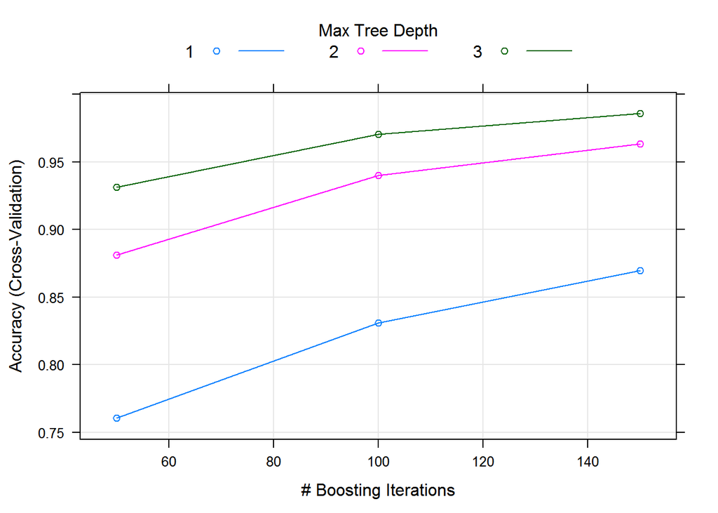

```r
plot(model.fit)
```

For training data we have following confusion matrix.

```r
pred.train <- predict(model.fit, newdata = training)
confMtx.Train <- confusionMatrix(pred.train, training$classe)
confMtx.Train
```

```
## Confusion Matrix and Statistics
##
##           Reference
## Prediction    A    B    C    D    E
##          A 3904   10    0    0    0
##          B    2 2629   19    2    2
##          C    0   18 2374   20    3
##          D    0    1    3 2229   12
##          E    0    0    0    1 2508
##
## Overall Statistics
##
##                Accuracy : 0.9932
##                  95% CI : (0.9917, 0.9945)
##     No Information Rate : 0.2843
##     P-Value [Acc > NIR] : < 2.2e-16
##
##                   Kappa : 0.9914
##  Mcnemar's Test P-Value : NA
##
## Statistics by Class:
##
##                      Class: A Class: B Class: C Class: D Class: E
## Sensitivity            0.9995   0.9891   0.9908   0.9898   0.9933
## Specificity            0.9990   0.9977   0.9964   0.9986   0.9999
## Pos Pred Value         0.9974   0.9906   0.9830   0.9929   0.9996
## Neg Pred Value         0.9998   0.9974   0.9981   0.9980   0.9985
## Prevalence             0.2843   0.1935   0.1744   0.1639   0.1838
## Detection Rate         0.2842   0.1914   0.1728   0.1623   0.1826
## Detection Prevalence   0.2849   0.1932   0.1758   0.1634   0.1826
## Balanced Accuracy      0.9992   0.9934   0.9936   0.9942   0.9966
```

Here we can see the model accuracy is *0.99323*.  
Now we can estimate the model with test data set.

```r
# predict on test data
pred.test <- predict(model.fit, newdata = testing)
# build confusion matrix
confMtx.Test <- confusionMatrix(pred.test, testing$classe)
confMtx.Test
```

```
## Confusion Matrix and Statistics
##
##           Reference
## Prediction    A    B    C    D    E
##          A 1674    6    0    0    0
##          B    0 1129   10    3    5
##          C    0    4 1014    9    1
##          D    0    0    1  951    4
##          E    0    0    1    1 1072
##
## Overall Statistics
##
##                Accuracy : 0.9924
##                  95% CI : (0.9898, 0.9944)
##     No Information Rate : 0.2845
##     P-Value [Acc > NIR] : < 2.2e-16
##
##                   Kappa : 0.9903
##  Mcnemar's Test P-Value : NA
##
## Statistics by Class:
##
##                      Class: A Class: B Class: C Class: D Class: E
## Sensitivity            1.0000   0.9912   0.9883   0.9865   0.9908
## Specificity            0.9986   0.9962   0.9971   0.9990   0.9996
## Pos Pred Value         0.9964   0.9843   0.9864   0.9948   0.9981
## Neg Pred Value         1.0000   0.9979   0.9975   0.9974   0.9979
## Prevalence             0.2845   0.1935   0.1743   0.1638   0.1839
## Detection Rate         0.2845   0.1918   0.1723   0.1616   0.1822
## Detection Prevalence   0.2855   0.1949   0.1747   0.1624   0.1825
## Balanced Accuracy      0.9993   0.9937   0.9927   0.9927   0.9952
```

For testing dataset, we also have pretty high accuracy *0.9923534*.